# Exploring Data

Dr. Liu Qizhang

12 February 2019

## Introduction

This file covers data exploration, such as missing data, data exploration and a basic introduction to ggplot2. Below we have the code to import the two datasets used this week.

```r
property <- read.csv("property.csv")
customers <- read.csv("customers.csv")
```

## Missing Data

Sometimes we may simply choose to remove any observations where there are missing data, such as the following.

```r
property <- property[complete.cases(property), ]
```

However, we may lose some important insight if we simply remove any incomplete observations. More importantly, blindly doing so without checking the data and even overwriting the original dataset can be dangerous.

```r
dim(property)
```

```
## [1]  0 20
```

Notice that we now have zero observations and we will have to reimport the data because of our blind overwrite.

### Causes of Missing Data

```r
property <- read.csv("property.csv")
property[37:40, c("Property.Type.", "Developer.", "HDB.Town.")]
```

```
##    Property.Type.                            Developer.   HDB.Town.
## 37    Condominium Sim Lian JV (Punggol Central) Pte Ltd        <NA>
## 38    Condominium               Hong Leong Holdings Ltd        <NA>
## 39    HDB 5 Rooms                                  <NA>  Sembawang
## 40    HDB 5 Rooms                                  <NA>  Sembawang
```

The slice of data shows that logically each observation will have at least one field with an NA. It will either have NA for HDB Town if it is a condominium or an NA in the Developer field if it is an HDB.

Here we have **Structural Missing Data**, where data is designed to be missing for the specific nature of the business. Developers are not relevant to HDBs and HDB Towns are not relevant to condominiums.

It is important to understand the nature of missing data before we decide on a course of action to deal with them. We may be missing data due to **human error** in data entry or collection, **system error** in capturing data, or **loopholes** in the business process.

```r
property[1:13, c("Built.Year.", "Bathrooms.", "Floor.")]
```

```
##    Built.Year. Bathrooms.    Floor.
## 1         2010          4    GROUND
## 2         2015          1    GROUND
## 3           NA          1      <NA>
## 4         2016          2      HIGH
## 5         2016          2      HIGH
## 6         2016          2       MID
## 7         2016         NA      <NA>
## 8         2016          2       MID
## 9         2016          2      <NA>
## 10        2016          1      <NA>
## 11        2016         NA      <NA>
## 12        2010         NA      <NA>
## 13        2014          2 PENTHOUSE
```

Notice how many of the fields have NA values yet these properties should have a built year, bathrooms or a floor. It is likely due to some loophole in the business process, allowing for human operators to omit crucial data that is not structurally missing.

### Dealing with Missing Data

Before we can decide on how we deal with the missing data, it is usually a good idea to have an overview of the dataset. A good way is with the *summary()* function.

```r
summary(customers)
```

```
##        id          gender  is.employed         income
##  Min.   :   2068   F:440   Mode :logical   Min.   : -7600
##  1st Qu.: 345667   M:560   FALSE:73        1st Qu.: 14200
##  Median : 693403           TRUE :599       Median : 34500
##  Mean   : 698500           NA's :328       Mean   : 53648
##  3rd Qu.:1044606                           3rd Qu.: 68900
##  Max.   :1414286                           Max.   :454500
##                                            NA's   :73
##      marital.status bought.product                        housing.type
##  Divorced   :155    Mode :logical   Homeowner free and clear    :157
##  Ever Single:233    FALSE:159       Homeowner with mortgage/loan:412
##  Married    :516    TRUE :841       Rented                      :375
##  Widowed    : 96                    NA's                        : 56
##
##
##
##  is.member         num.cards          age                 district
##  Mode :logical   Min.   :0.000   Min.   :  0.0   WOODLANDS    : 29
##  FALSE:820       1st Qu.:1.000   1st Qu.: 38.0   BUKIT PANJANG: 28
##  TRUE :124       Median :2.000   Median : 50.0   BOON LAY     : 26
##  NA's :56        Mean   :1.916   Mean   : 51.7   MARINA EAST  : 25
##                  3rd Qu.:2.000   3rd Qu.: 64.0   OUTRAM       : 24
##                  Max.   :6.000   Max.   :146.7   SENGKANG     : 24
##                  NA's   :56                      (Other)      :844
##  no.family.members           industry
##  Min.   :1.000     IT            :104
##  1st Qu.:2.000     Finance       :100
##  Median :4.000     Others        : 99
##  Mean   :4.485     Transportation: 97
##  3rd Qu.:7.000     Education     : 95
##  Max.   :8.000     (Other)       :177
##                    NA's          :328
```

The *summary()* function helpfully tells us how much data is missing in each field with its “NA’s” row.

We may have **missing categorical data**, such as in the case of the “is.employed” field. An easy solution would be to set a new category called “Unknown” for these missing records.

```r
attach(customers)
customers$employment.status <- ifelse(is.na(is.employed),
                                      "Unknown",
                                      ifelse(is.employed,
                                             "Employed",
                                             "Unemployed"))
```

Notice that we choose to create a new field called “employment.status” instead of adding “Unknown” into the existing field “is.employed”. This is so that we retain our original data and can easily investigate should anything go wrong.

If we have **missing numerical data**, then it will be a bit more complex. Should data be missing randomly, then we may assign the mean value of the existing data to it or we can assign a value based on its relationship to other related variables.

We may be able to estimate missing income data with age or profession.

Sometimes, we may even have numerical missing data might be **structural**. For example, those below 20 or above 65 might not have any income at all.

Depending on the research objective, we can assign zeros to the missing data so that we can analyze our data numerically. Since these age groups will not be working, their income will indeed be 0.

```r
customers$income.fix <- ifelse(is.na(income), 0, income)
```

However, if our interest is in different income levels, we might convert the numerical data into categorical data.

We will first create a vector representing the thresholds to classify income groups. This is like specifying our bin ranges in excel.

```r
b <- c(0, 10000, 50000, 100000, 250000, 1000000)
```

Next, we will use the *cut()* function to break incomes into income groups and then convert the result into the character data type.

```r
income.groups <- cut(income, breaks=b, include.lowest = TRUE)
income.groups <- as.character(income.groups)
```

Now, we will then name the missing data as “No Income”.

```r
income.groups <- ifelse(is.na(income.groups),
                        "No Income",
                        income.groups)
```

Finally, we assign this vector as a new variable in the customers data frame.

```r
customers$income.groups <- income.groups
```

These are just some common methods to handle missing data, the method to use depends on the nature of the data, your research interest, and your understanding of the data.

As you try this out yourself, remember to “detach” the customers dataset afterward.

```r
detach(customers)
```

### Other Data Problems

While missing data is the most common data problem we may face, it is considered an explicit data problem and as such, relatively easy to identify and deal with.

There can be other data problems that are hard to identify and yet may have a deep impact on our research if we do not handle it properly.

Data problems are normally caused by data entry mistakes, logical error, outdated data or inconsistent standards.

**Data entry problems** are usually easily spotted, notice that the minimum income below is -7600. It is very likely a data entry mistake, however, it is possible that debt may be recorded as negative income in this dataset. This needs to be clarified with the data provider, if possible.

**Logical errors** in data could be due to logical mistakes in the system the data was generated from. It could also be mishandling by a data processor if it is secondary data.

Strong domain knowledge and logical thinking are necessary to identify such a data problem.

**Outdated data**, even if perfect in quality, cannot be used in context-based and time-sensitive projects. An example is in predicting stock market movement.

**Inconsistent data** can result from multiple standards co-existing in a single dataset. This may occur as data originates from different sources, or have different people processing it.

Inconsistent data resulted in NASA losing its $125 million Mars Climate Orbiter in 1999.

A navigation team at the Jet Propulsion Laboratory used the Metric System’s millimeters and meters in its calculations. Lockheed Martin Astronautics in Denver, who designed and built the spacecraft, provided crucial acceleration data in the Imperial System’s inches, feet, and pounds.

As a result, JPL engineers mistook acceleration readings measured in Imperial units of pound-seconds for a metric measure of force called newton-seconds.

In a sense, the spacecraft was lost because of data inconsistency.

## Data Visualization

Being able to communicate in data sense is an essential skill. Stephen Few, a famous data visualization expert, pointed out: “Numbers have an important story to tell. They rely on you to give them a clear and convincing voice.” Findings from data projects can only be convincing and persuasive if presented properly. Visualization is the most effective way to do so. In Scott Berinato’s [HBR article](https://hbr.org/2016/06/visualizations-that-really-work), he classifies data visualization into four main types: idea illustration, idea generation, everyday DataViz, and visual discovery.

**Visual discovery** is probably the most valuable type of data visualization. Its goals include trend spotting, sense-making, and deep analysis.

In descriptive analytics, mentions of data visualizations usually refer to visual discovery. A good example of the power of visual discovery was in the 2016 [rogue train case](https://blog.data.gov.sg/how-we-caught-the-circle-line-rogue-train-with-data-79405c86ab6a)

### Principles of Data Visualization

There are eight core principles, as specified by Stephen Few.

Principle 1 - **Simplify**, it is not the more the better. Good data visualization capture the essence of data.

Principle 2 - **Compare**, it is always good to compare data visualizations side by side. The audience will be able to spot trends, patterns or differences with their eyes.

Principle 3 - **Attend**, good data visualization should highlight details we need the audience to attend to.

Principle 4 - **Explore**, good data visualization should allow the audience to explore data and discover things visually.

Principle 5 - **View diversely**, it is helpful to look at the same data from different perspectives concurrently and see how they fit together.

Principle 6 - **Ask why**, good data visualization should allow audiences to dig into the facts and find out why things are happening.

Principle 7 - **Be skeptical**, don’t be content with the first answer we get. Drill down into the data and explore further.

Principle 8 - **Respond**, just exploring the data alone has limited benefit. Being able to share your data visually will lead to global enlightenment.

## Ggplot2 Package

We will be making use of the ggplot2 package from the tidyverse family of packages. We can either install and load *tidyverse* or *ggplot2*. Last week, we already made use of the plotting capabilities that come in-built with R.

However, ggplot2 allows us to make complex and aesthetically pleasing plots quickly and intuitively from a beginner’s standpoint. This is possible with the ‘grammar of graphics’ - the gg in ggplot. With a relatively modest set of ggplot building blocks and grammar, we can create hundreds of plots. Its default plot behavior is also designed to satisfy a majority of cases whilst still aesthetically pleasing.

One limitation is that ggplot is build to work exclusively with data tables - where rows have to be observations and columns variables. We will have to memorize the names of several functions and arguments, as such a [ggplot2 cheatsheat](https://www.rstudio.com/wp-content/uploads/2015/03/ggplot2-cheatsheet.pdf) is recommended.

### Graph Components

We will make use of dslab’s murders dataset to look at graph components.

```r
library(dslabs)
data(murders)
```

Also ensure that either *tidyverse* or *ggplot2* is installed and loaded, in my case its ggplot2.

```r
library(ggplot2)
```

As motivation, below is the target graph we want to make.

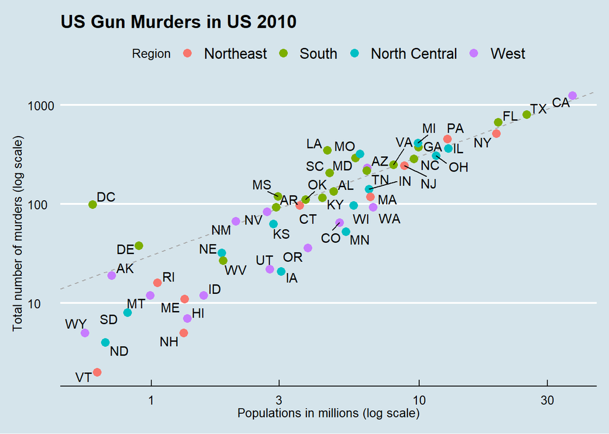

The first step in learning ggplot2 is to be able to break a graph into components. The main *three* components we have to be aware of are:

1. The **data component**, the US murders data table in the example plot is summarized.
2. The **geometry component**, the example plot is a scatter plot. We also have bar plots histograms, smooth densities, q-q plots, and blocks plots.
3. The **aesthetic mapping component**, the x-axis values are used to display population size, while the y-axis values are used to display the total number of murders. Text is used to identify the states, and colors are used to denote the four different regions. These mappings depend on what geometry is used

*Other components* worth mentioning:

4. The **scale component**, the range of x-axis and y-axis appear to be defined by the range of the data, and in this case, are both on log scales.
5. The **labels, title, legend, etc**, the example plot uses the style used by The Economist magazine.

### Creating a New Plot

Firstly, in order to create a ggplot graph, we must define a ggplot object. This is done with the *ggplot()* function, which initializes the graph.

The first argument in the *ggplot()* function is used to specify the graph’s data component.

```r
ggplot(data = murders)
```

This associates the dataset with the plotting object. However, we can also pipe the data equivalently.

```r
murders %>% ggplot()
```

These both render a plot, however they are blank with a grey style background due to the lacking geometry component. As they were not assigned, they are automatically evaluated.

```r
p <- ggplot(data = murders)
class(p)
```

```
## [1] "gg"     "ggplot"
```

When assigned instead, we must now either use the *print()* function or simply call the variable.

```r
print(p)
```

```r
p
```

### Layers

In ggplot, we create graphs by adding layers. This is done as a component by component. These layers can define geometries, compute summary statistics, define what scales to use, and even change styles. To add layers, we use the symbol plus “+”. Below we have some typical pseudocode.

```r
DATA %>% ggplot() + LAYER 1 + LAYER 2 + ... + LAYER N
```

Usually, layer 1 defines the geometry component. As we want to make a scatterplot in the example plot, we will be using ggplot’s *geom_point()* function. Geometry functions, in general, follow the pattern of “geom_” + name reminiscent to the geometry.

The *geom_point()* function, needs both the data component and the aesthetic mapping component. We have already connected the data component - the murders data table. To understand what mappings are required, we read the aesthetics section of the help file.

```r
?geom_point
```

The required aesthetics under the aesthetics section are in bold. In this case, they are x and y - the x and y of the plot.

The *aes()* function connects data with what we see on the graph - this connection is called the aesthetic mappings. The output of this function is usually used as an argument of a geometry function.

The following example produces a scatterplot of total murders versus population in millions.

```r
murders %>% ggplot() +
  geom_point(aes(x = population/10^6, y = total))
```

We pipe the murders dataset into ggplot, and then we add a layer with a *geom_point()* function. We can see that we’re assigning population to x and total to y. We can actually drop the ‘x’ and the ‘y’ as they are the first and second expected arguments.

```r
murders %>% ggplot() +
  geom_point(aes(population/10^6, total))
```

In ggplot, we can also add layers to previously defined objects.

```r
p <- ggplot(data = murders)
p + geom_point(aes(population/10^6, total))
```

Note that this will render the object, as we did not assign it to a new object in the last line above.

The scales and labels are defined by default when adding this layer - the variable names from the object component are used to label the axes. The *aes()* function recognizes variables from the data component. This is specific to *aes()*.

The second layer we wish to make involves adding a label to each point, as it helps us identify the state the point denotes. We will use the *geom_label()* and *geom_text()* functions to add text to the plot. Use label for a label with a rectangle and text to simply add text.

As each point needs a label, we will have to use the aesthetic mapping component to make this connection. Again, let’s look at the help file.

```r
?geom_text
```

The aesthetics section tells us that we supply the mapping between point and label through the label argument of aes.

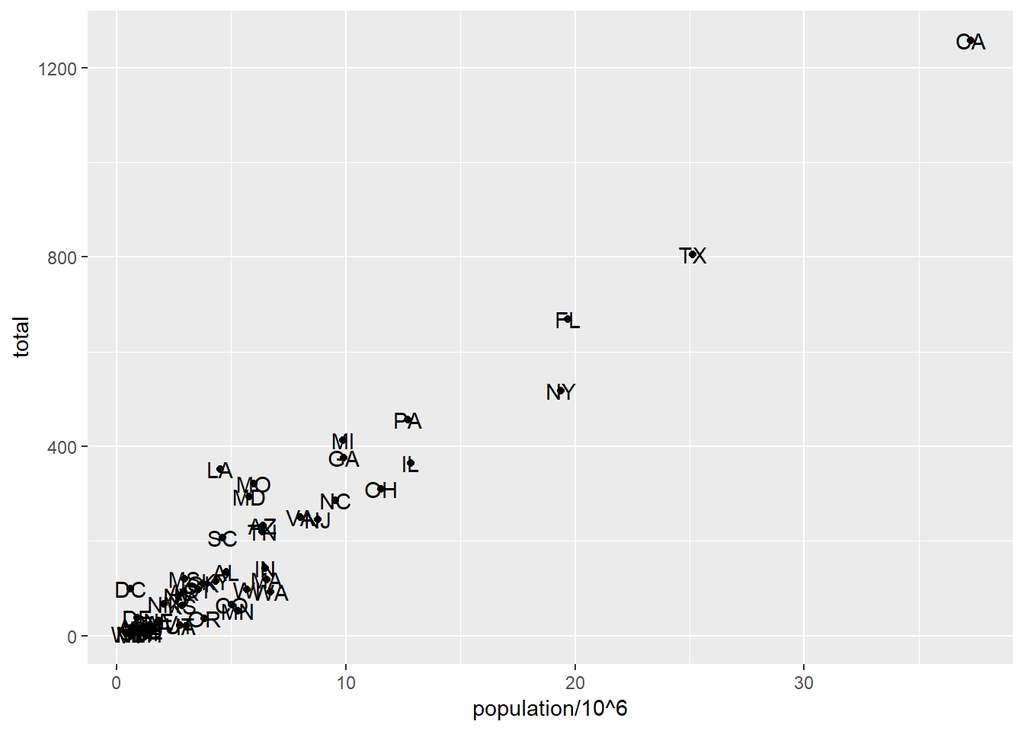

```r
p + geom_point(aes(population/10^6, total)) +
  geom_text(aes(population/10^6, total, label = abb))
```

We use the state abbreviations, stored in the “abb” variable.

Note that if we were to move label out of aes, we will get an error, as “abb” will not be found out of aes - not a globally defined variable.

```r
p_test <- p + geom_text(aes(population/10^6, total), label = abb)
```

### Tinkering

Each geometry function in ggplot has many other arguments other than aes and data, however, they tend to be specific to the plot. We wish to make the points larger than the default.

```r
?geom_point
```

We can see that size is an aesthetic and can be changed using the code below.

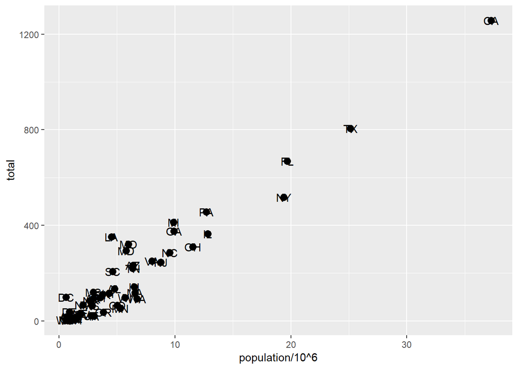

```r
p + geom_point(aes(population/10^6, total), size = 3) +
  geom_text(aes(population/10^6, total, label = abb))
```

We put the size argument outside of aes. Size is not a mapping, it affects all the points the same and was outside of aes. We now need to shift the labels due to the points being larger.

```r
?geom_text
```

The help file above shows that we can do so with the *nudge_x* argument.

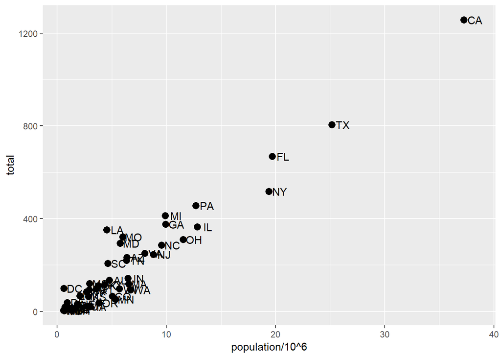

```r
p + geom_point(aes(population/10^6, total), size = 3) +
  geom_text(aes(population/10^6, total, label = abb), nudge_x = 1)
```

Nudge_x = 1 moves all geom_text labels slightly to the right, allowing us to read it.

So far, we have been quite inefficient by mapping population and total twice. Instead, we can avoid this by adding a global aesthetic mapping. This has to be done as we define the blank slate - at the *ggplot()* function, it has an argument for us to define aesthetic mappings.

We can check all arguments a function has with the *args()* function.

```r
args(ggplot)
```

```
## function (data = NULL, mapping = aes(), ..., environment = parent.frame())
## NULL
```

However, if we define a global aesthetic mapping in ggplot, then all geometries added as layers will default to this global.

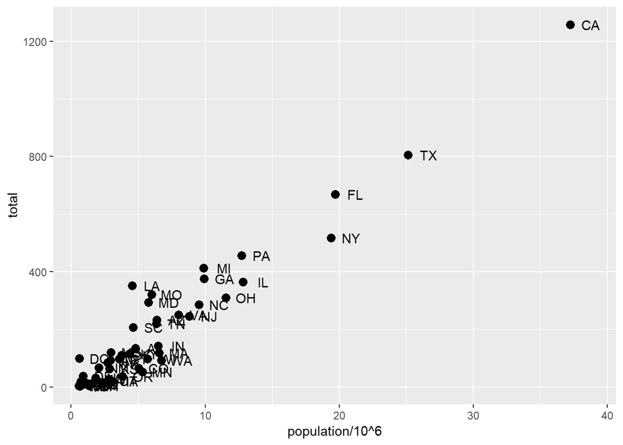

```r
p <- murders %>% ggplot(aes(population/10^6, total, label = abb))
p + geom_point(size = 3) +
  geom_text(nudge_x = 1.5)
```

Note that the arguments kept in *geom_point()* and *geom_text()* are specific only to those two geometries and so must be kept there. The *geom_point()* did not need the label argument, so simply ignored it.

To override global mappings, we simply use local mappings to override this.

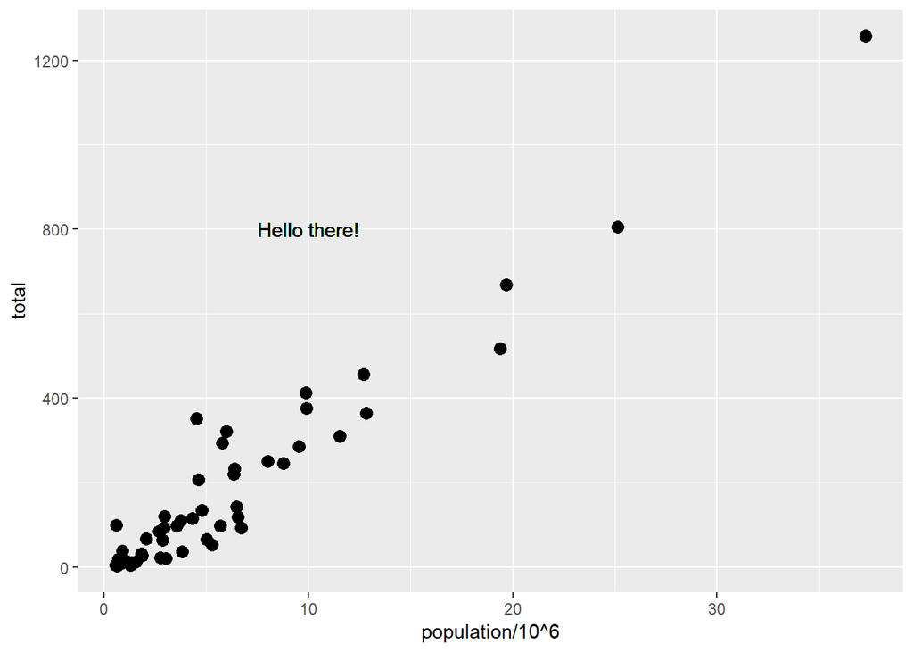

```r
p + geom_point(size = 3) +
  geom_text(aes(x = 10, y = 800, label = "Hello there!"))
```

The plot produced above shows that the labels are no longer there, the local label argument is used instead.

### Scales, Labels, and Colors

To change our scales to the log scales for our example, we need to use the scales layer. We can use the *scales_x_continuous()* function to edit the behavior of scales.

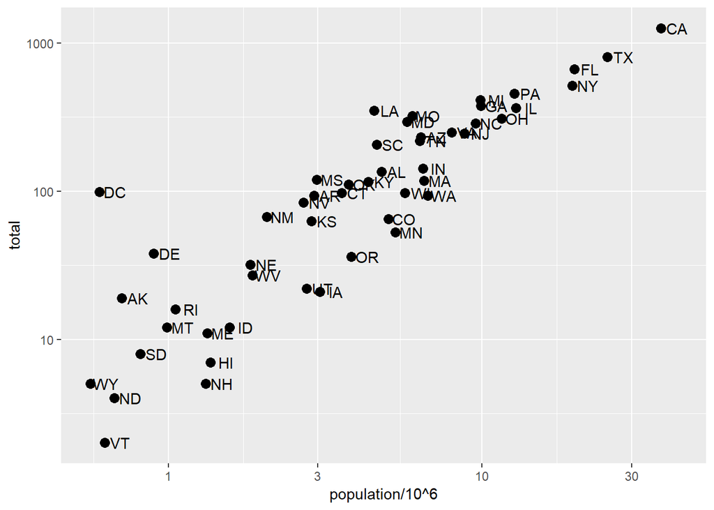

```r
p <- murders %>% ggplot(aes(population/10^6, total, label = abb))
p + geom_point(size = 3) +
  geom_text(nudge_x = 0.05) +
  scale_x_continuous(trans = "log10") +
  scale_y_continuous(trans = "log10")
```

Notice that the nudge must be smaller due to a change in scale. The log transformation is also common enough that ggplot provides specialized functions.

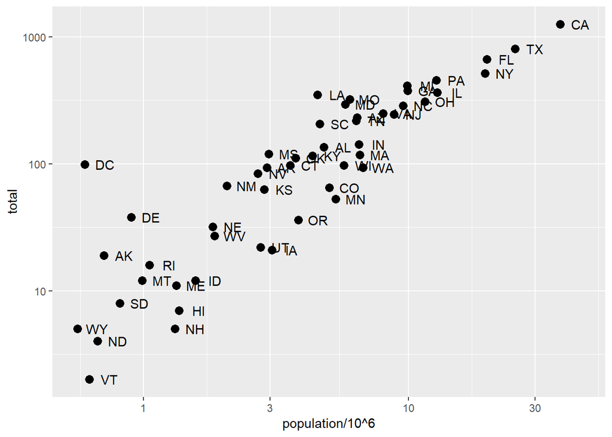

```r
p + geom_point(size = 3) +
  geom_text(nudge_x = 0.075) +
  scale_x_log10() +
  scale_y_log10()
```

We can use *xlab()* and *ylab()* functions to add labels to the respective axes, and *ggtitle()* to add a title to our plot.

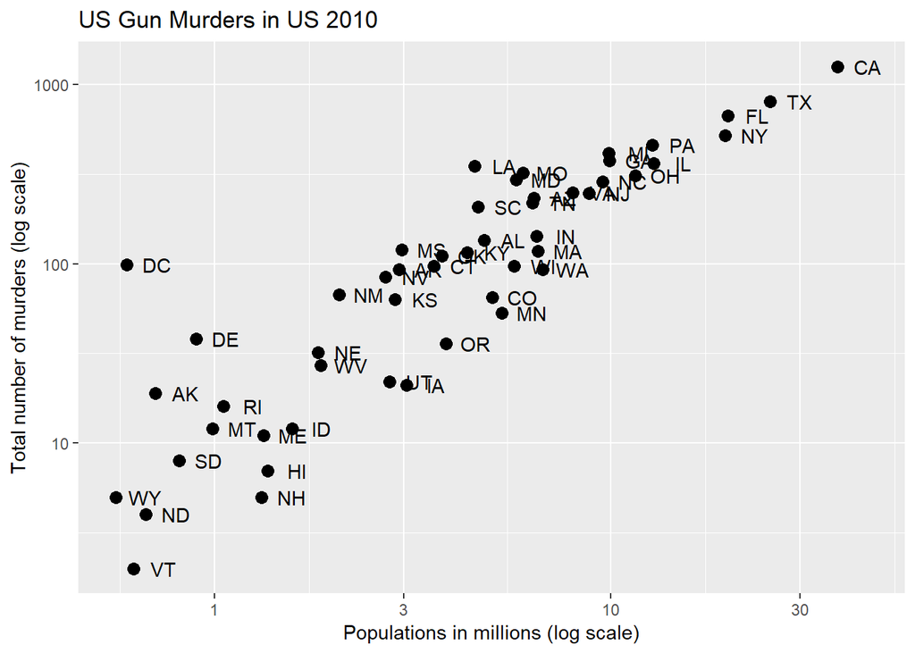

```r
p + geom_point(size = 3) +
  geom_text(nudge_x = 0.075) +
  scale_x_log10() +
  scale_y_log10() +
  xlab("Populations in millions (log scale)") +
  ylab("Total number of murders (log scale)") +
  ggtitle("US Gun Murders in US 2010")
```

We can change the color of our points in the plot using the “color” argument in the *geom_point()* function.

In order to slowly try out the effects of changing color on our plot, we can save what we have done so far by assigning it to p.

```r
p <- murders %>% ggplot(aes(population/10^6, total, label = abb)) +
  geom_text(nudge_x = 0.075) +
  scale_x_log10() +
  scale_y_log10() +
  xlab("Populations in millions (log scale)") +
  ylab("Total number of murders (log scale)") +
  ggtitle("US Gun Murders in US 2010")
```

To make our points blue, we use “blue” for the color argument.

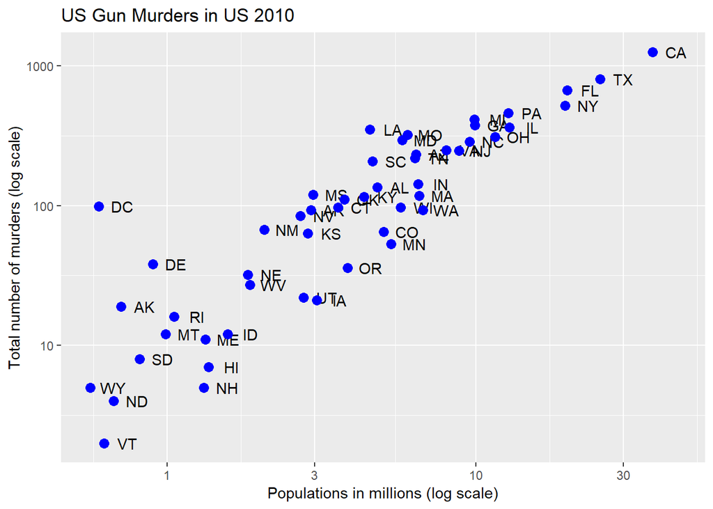

```r
p + geom_point(size = 3, color = "blue")
```

However, we want the color to be associated with geographical regions. By default, if we assign a categorical variable to the color argument, it will automatically assign a different color for each category and also adds a legend.

We will need to use mapping, so we have to use aes.

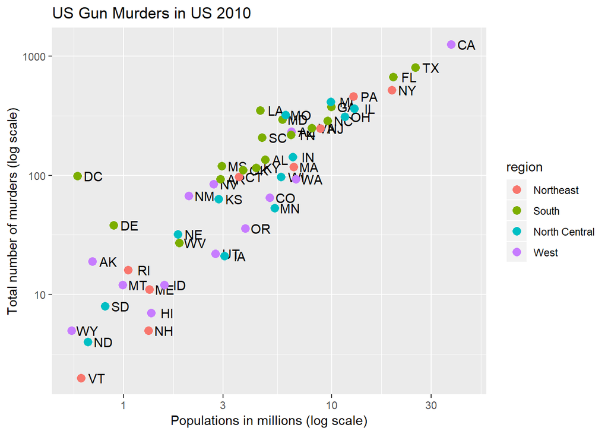

```r
p + geom_point(aes(col=region), size = 3)
```

Notice that the “col” argument is inside aes, while size is still outside. The x & y mapping was already defined earlier in the global aesthetic mapping and so do not have to be repeated here.

We also want to add a line that represents the average murder rate in the entire country. Once we determine the per million rate to be “r”, the line will be y = r*x.

We will make use of dplyr to find the murder rate.

```r
library(dplyr)
r <- murders %>%
  summarize(rate = sum(total) / sum(population) * 10^6) %>% .$rate
```

To add a line, we use the *geom_abline()* function. Ggplot uses ‘ab’ in the name to remind us we’re supplying the intercept a and slope b. The default line for *geom_abline()* has slope 1, intercept 0. This means we only have to specify the intercept.

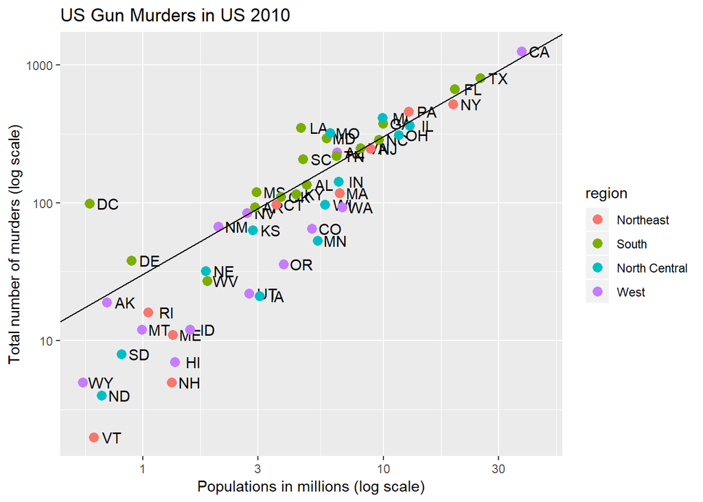

```r
p + geom_point(aes(col=region), size = 3) +
  geom_abline(intercept = log10(r))
```

To recreate the original plot, we have to change the line type from solid to dashed, change the color from black to grey, and also, we need to draw the line before the points. This is so that the line will be in the background relative to the points. ‘lty’ = 2 changes the line type to dashed and ‘color’ for abline is for the line itself.

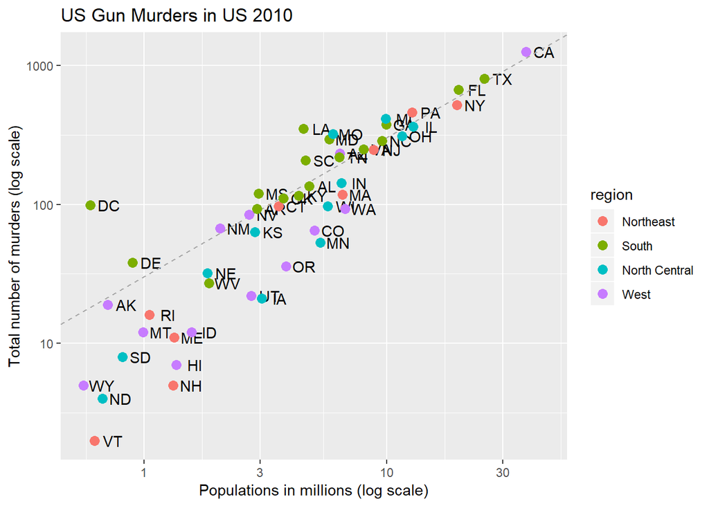

```r
p <- p +
  geom_abline(intercept = log10(r), lty = 2, color = "darkgrey") +
  geom_point(aes(col=region), size = 3)
p
```

Also, notice that abline is now before point.

Ggplot is very flexible that any small changes that you might want to make are always possible. One such small change is to capitalize the word region in the legend.

We can do this with *scale_color_discrete()* function.

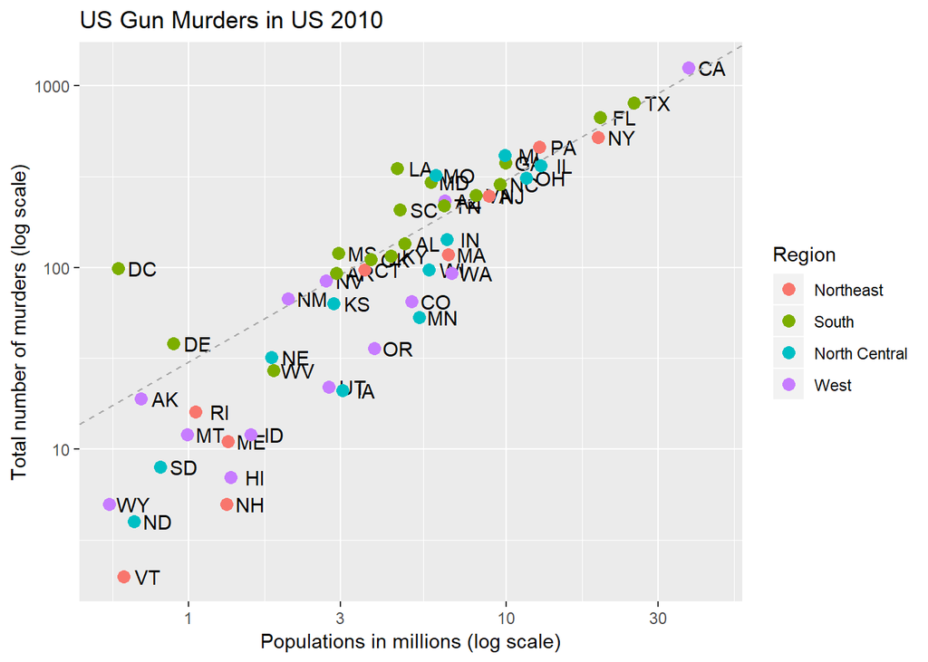

```r
p <- p + scale_color_discrete(name = "Region")
p
```

### Add On Packages

Ggplot allows us to use additional add on packages in order to further extend its functionality. We will be exploring the *ggthemes* and *ggrepel* add on packages in order to duplicate the example graph.

The style of a ggplot graph can be changed using the theme function. Several themes are included as part of the ggplot2 package.

We will be installing and loading *ggthemes* and then using the *theme_economist()*.

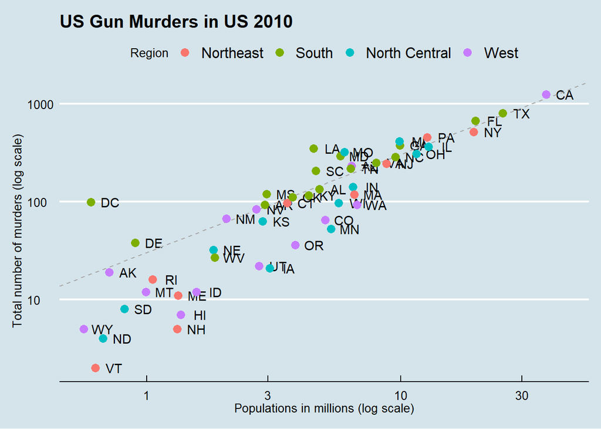

```r
library(ggthemes)
p + theme_economist()
```

Simply change the trailing function from this point to try out other themes.

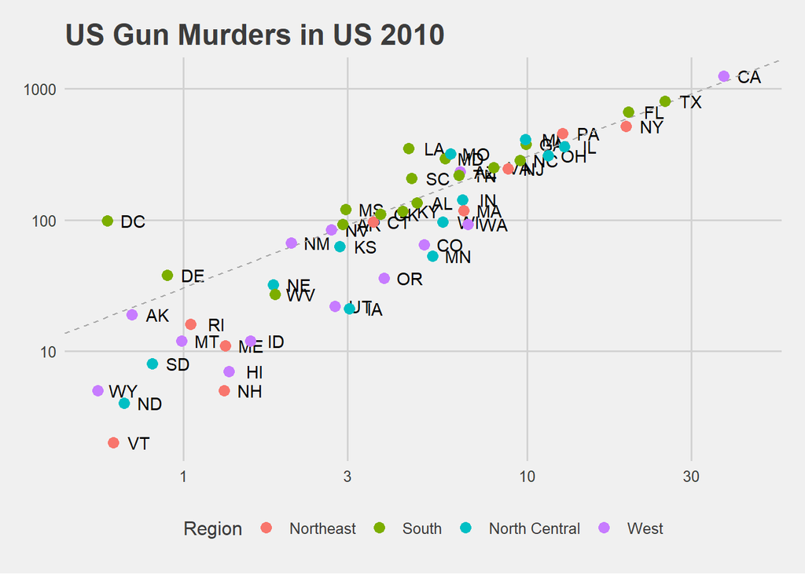

```r
p + theme_fivethirtyeight()
```

Finally, we just want to reposition our labels. Currently, some of the labels overlap, making it hard to read.

This is where *ggrepel* comes in, it can add geometry for labels to ensure this behavior is avoided. We simply need to change the *geom_text()* layer a *geom_text_repel()* layer instead.

From scratch, these are **all steps** in the correct order.

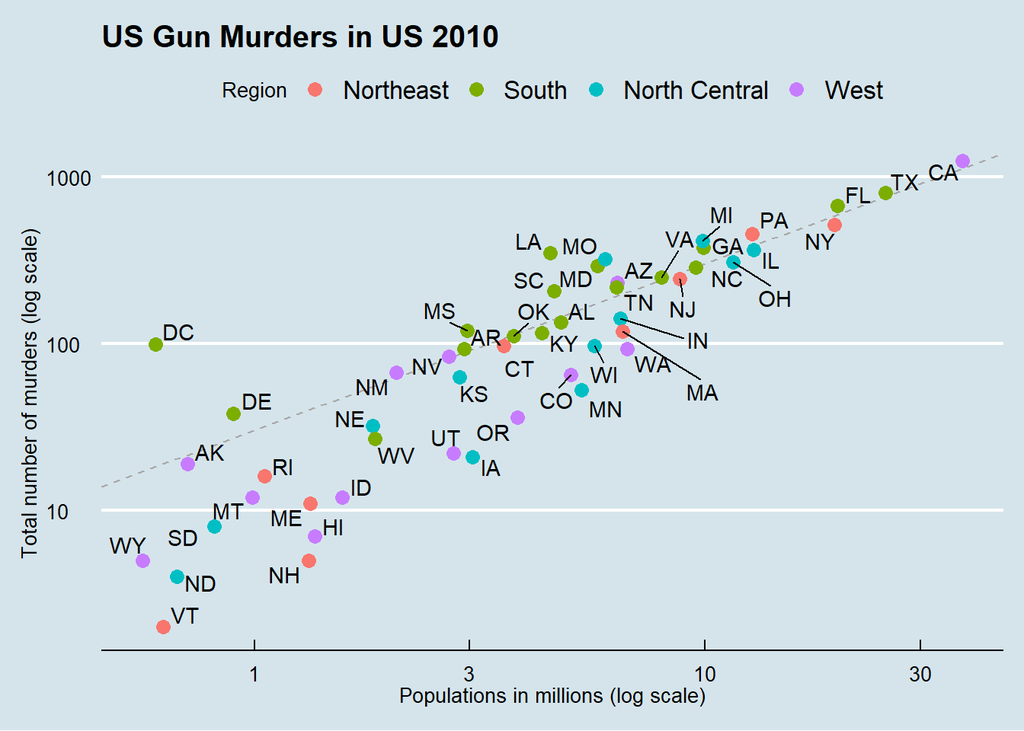

```r
library(ggthemes)
library(ggrepel)
### First define the slope of the line
r <- murders %>%
  summarize(rate = sum(total) / sum(population) * 10^6) %>% .$rate
## Now make the plot
murders %>% ggplot(aes(population/10^6, total, label = abb)) +
  geom_abline(intercept = log10(r), lty = 2, color = "darkgrey") +
  geom_point(aes(col=region), size = 3) +
  geom_text_repel() +
  scale_x_log10() +
  scale_y_log10() +
  xlab("Populations in millions (log scale)") +
  ylab("Total number of murders (log scale)") +
  ggtitle("US Gun Murders in US 2010") +
  scale_color_discrete(name = "Region") +
  theme_economist()
```

### Other Examples

Now that we know ggplot, we can try to make some of the summary plots we have previously described, starting with the histogram.

```r
library(dslabs)
data(heights)
#heights %>% filter(sex=="Male") try this line yourself
```

Now, we will be using *geom_histogram()*, notice the naming consistency between ggplot functions. From the help file, we can see that only the value x is needed to construct a histogram.

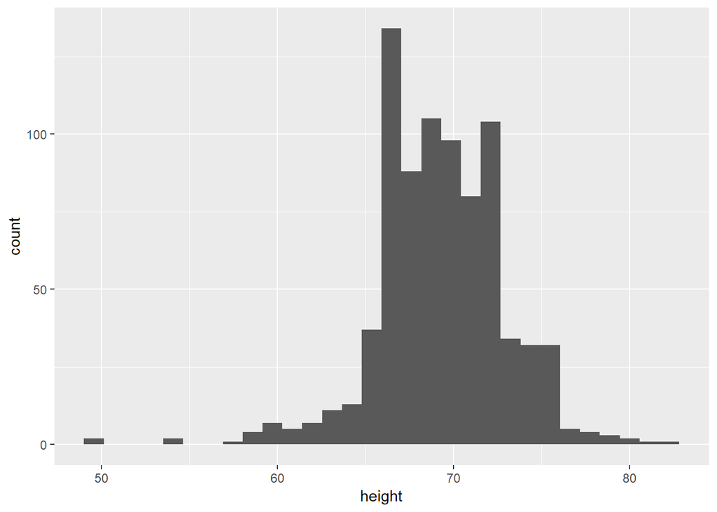

```r
p <- heights %>%
  filter(sex=="Male") %>%
  ggplot(aes(x = height))
p + geom_histogram()
```

Notice that we get a warning telling us that as bin width was not specified it was selected for us. Here we will use binwidth = 1.

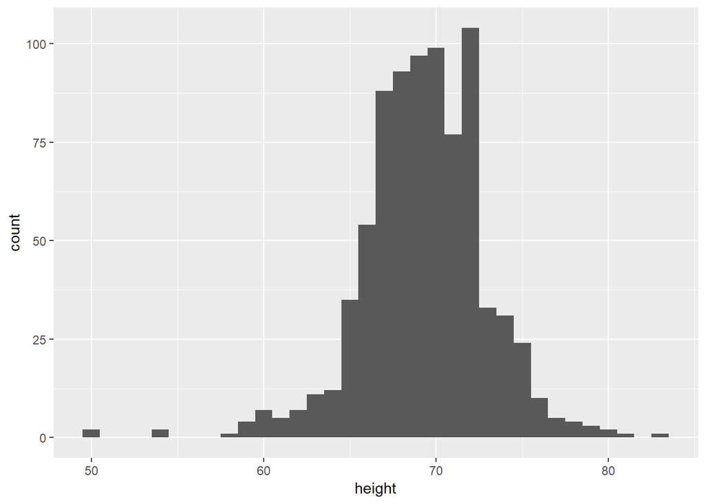

```r
p + geom_histogram(binwidth = 1)
```

To display the flexibility of ggplot, we will change the colors and add a title.

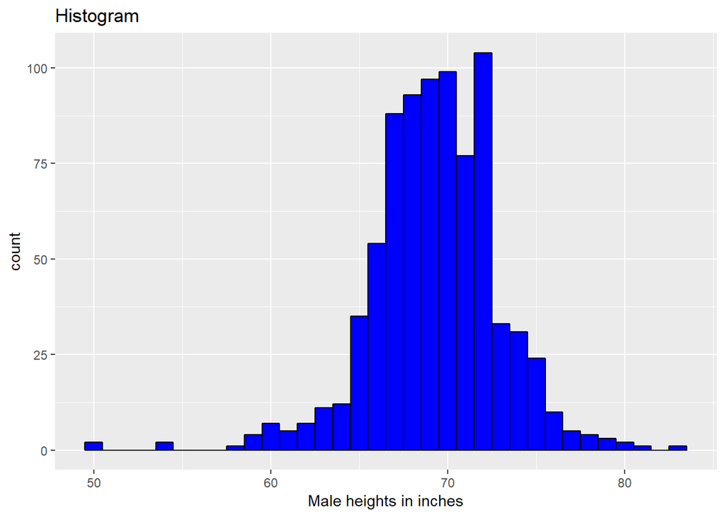

```r
p + geom_histogram(binwidth = 1, fill = "blue", col = "black") +
  xlab("Male heights in inches") +
  ggtitle("Histogram")
```

Note that ‘fill’ is for the bar itself, while ‘col’ is for the outline.

We can also create smooth densities with the *geom_density()* function. Instead of *geom_histogram()* above, we use this instead.

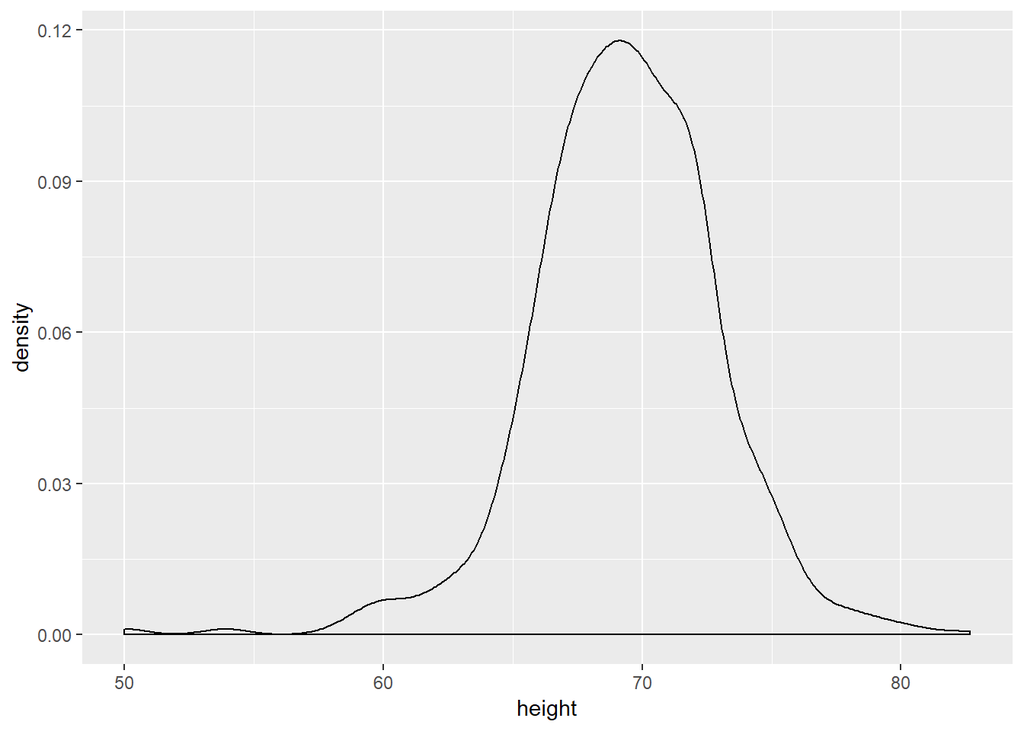

```r
p + geom_density()
```

To add color, we simply use the ‘fill’ argument.

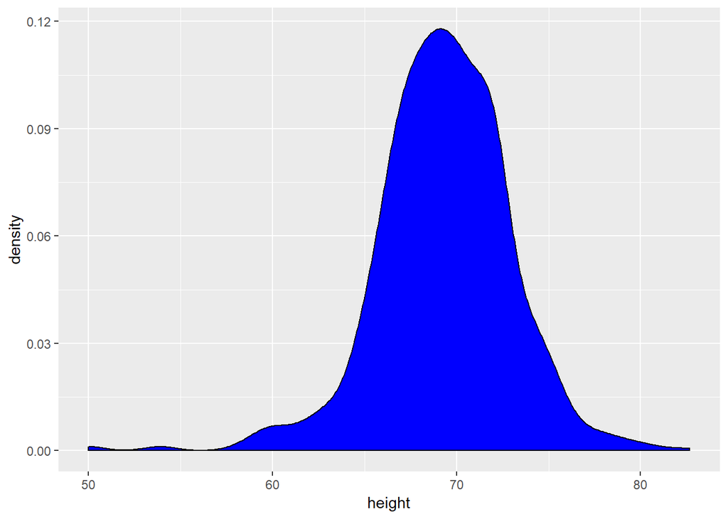

```r
p + geom_density(fill = "blue")
```

For q-q plots, we make use of the *geom_qq()* geometry. From the help file, we learn that we need to specify the sample argument. Instead of x, it now takes in sample. Therefore, we need to change our p.

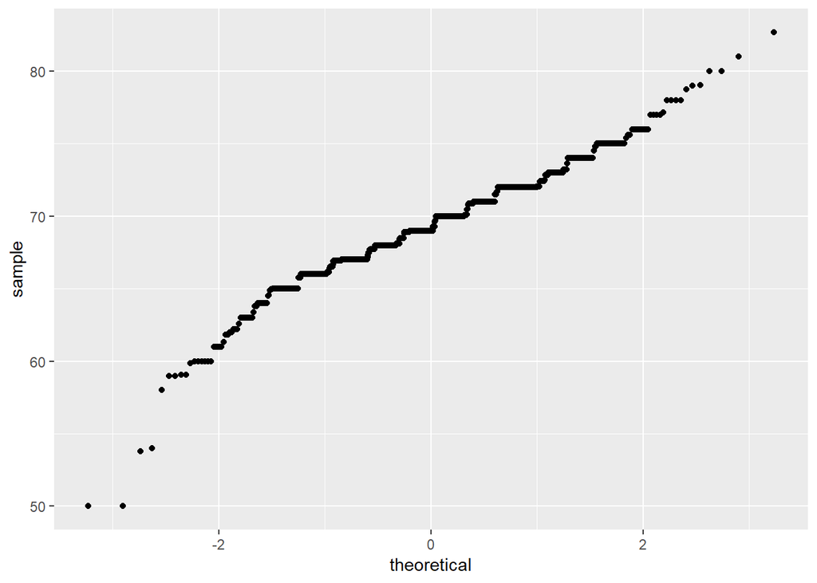

```r
p <- heights %>%
  filter(sex=="Male") %>%
  ggplot(aes(sample = height))
p + geom_qq()
```

Note that by default the q-q plot is compared to the normal distribution with average = 0 and standard deviation = 1. The standard normal distribution.

From the help file, we know that we can change this with the dparams argument. Now we just need to define an object ‘params’ that will have the mean and standard deviation of our data using some dplyr functions.

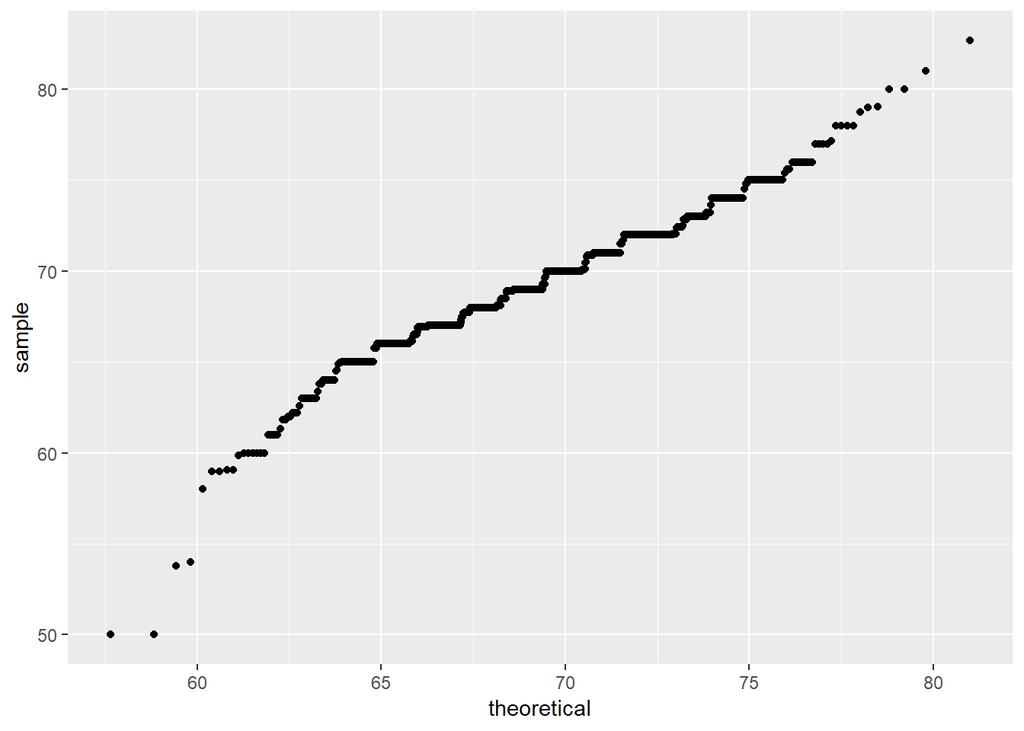

```r
params <- heights %>%
  filter(sex == "Male") %>%
  summarise(mean = mean(height), sd = sd(height))
p + geom_qq(dparams = params)
```

Now the q-q plot is plotted against a normal distribution with the same mean and standard deviation as our data.

We can now add identity lines to see just how well the normal approximation works. This is done with the *geom_abline()* layer.

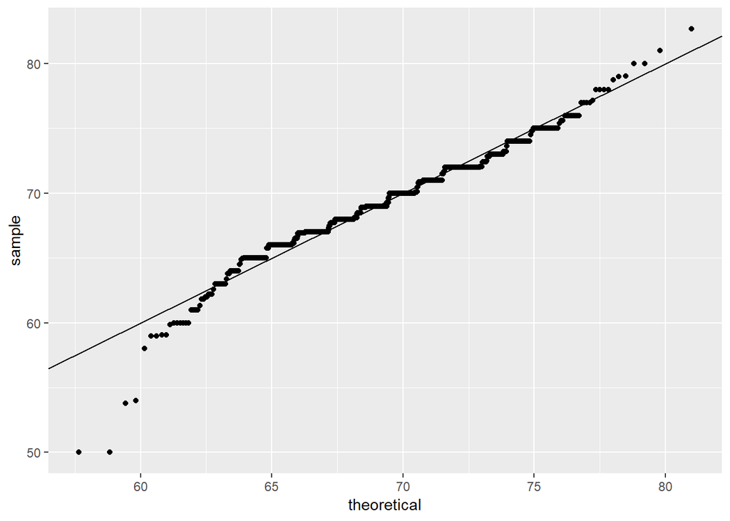

```r
p + geom_qq(dparams = params) +
  geom_abline()
```

Alternatively, we can scale the data in standard units before plotting it against the standard normal distribution, saving us the step of having to compute the mean and standard deviation of our dataset.

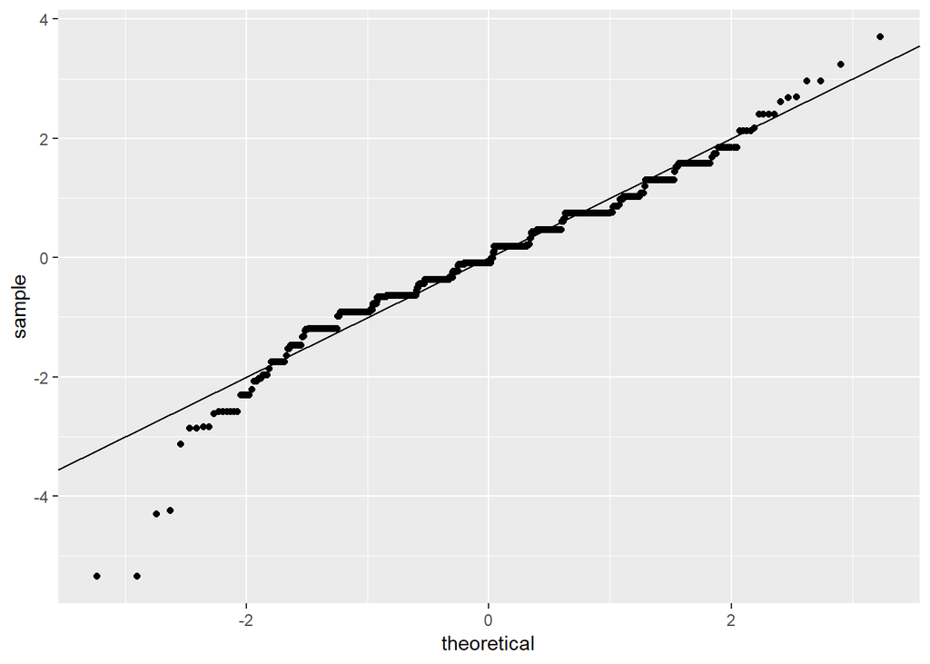

```r
heights %>% filter(sex=="Male") %>%
  ggplot(aes(sample = scale(height))) +
  geom_qq() +
  geom_abline()
```

Notice that the code looks a little cleaner.

We can also make grids of plots. We can use the *gridExtra* package, which has a function *grid.arrange()*

Firstly, we must define and assign each plot to an object.

```r
p <- heights %>% filter(sex=="Male") %>% ggplot(aes(x = height))
p1 <- p + geom_histogram(binwidth = 1, fill = "blue", col = "black")
p2 <- p + geom_histogram(binwidth = 2, fill = "blue", col = "black")
p3 <- p + geom_histogram(binwidth = 3, fill = "blue", col = "black")
```

Then, to show them next to each other, we use the function *grid.arrange()*.

```r
library(gridExtra)
```

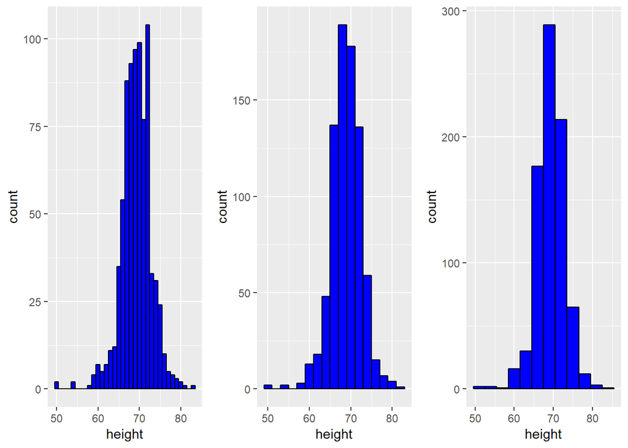

```r
grid.arrange(p1,p2,p3, ncol = 3)
```